# NetCDF and timeseries - mapping, cropping, correlating

M Campbell

01/10/2020

# 1 NetCDF Files

I have avoided NetCDF files like the plague - I always thought they were scary, and up until now I’ve been time-oriented, with little consideration for space (a poor trait in a geographer). I know everyone uses them, but I found it fairly hard to do some basic stuff (and find tutorials for basic stuff), so here’s a collection of simple steps for using spatio-temporal data with `ncdf4` and `raster` (and some other packages).

Below includes scripts and results to: 1. Map a layer from the GISTEMP temperature anomaly 2. Crop the GISTEMP raster brick 3. Correlate the time series for each cell of the raster brick by a synthetic time series (e.g. representative of a single station’s data, or a palaeoclimate proxy).

# 2 Packages

```r
library(rnaturalearth)
library(rnaturalearthdata)
library(ncdf4) # package for netcdf manipulation
library(raster) # package for raster manipulation
library(rgdal) # package for geospatial analysis
library(ggplot2)
library(rasterVis)
library(pals)
```

# 3 Data

I downloaded the ‘Surface air temperature (no ocean data), 250km smoothing’ compressed NetCDF file from the gistemp [page](https://data.giss.nasa.gov/gistemp/).

# 4 Mapping GISTEMP - the August 2020 temperature anomaly

```r
# data --------------------------------------------------------------------

nc_data <- nc_open("D:/CampbellM1/R_learning_space/gisstemp_2020/gistemp250_GHCNv4.nc")


# data cleaning -----------------------------------------------------------

{ # for looking at the data
  sink("gisstemp.txt")
  print(nc_data)
  sink()
}

lon <- ncvar_get(nc_data, "lon")
lat <- ncvar_get(nc_data, "lat")
t <- ncvar_get(nc_data, "time")
tdate <- as.Date(t, origin=c('1800-01-01')) ## convert time (days since 18000101 to date)


temp.array <- ncvar_get(nc_data, "tempanomaly") #extract temp anomaly data
fillvalue <- ncatt_get(nc_data, "tempanomaly", "_FillValue")
nc_close(nc_data)

temp.array[temp.array == fillvalue$value] <- NA ## replace fill value with NA
temp.slice <- temp.array[, , 1688] ## pulls one month(?) of data out.
dim(temp.slice)
```

```
## [1] 180  90
```

```r
dim(temp.array)
```

```
## [1]  180   90 1688
```

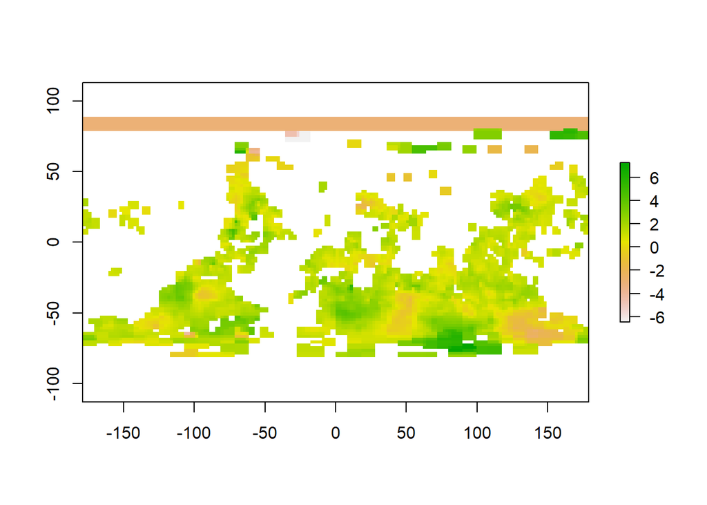

```r
r <- raster(t(temp.slice), xmn = min(lon), xmx = max(lon), ymn = min(lat), ymx = max(lat), crs = CRS("+proj=longlat +datum=WGS84 +no_defs"))
plot(r)
```

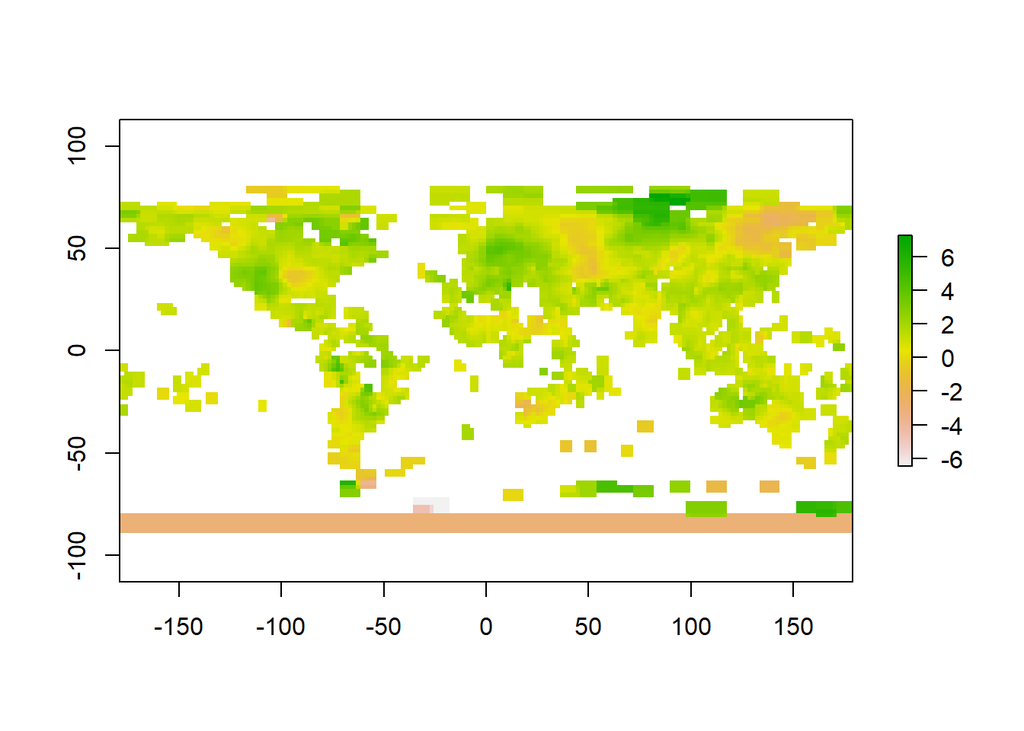

```r
r <- flip(r, direction = 'y')

plot(r)
```

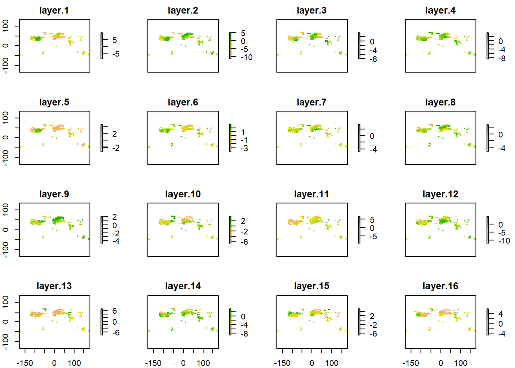

```r
### bricking collapses all layers into one object.
r_brick <- brick(temp.array, xmn=min(lat), xmx=max(lat), ymn=min(lon), ymx=max(lon), crs=CRS("+proj=longlat +datum=WGS84 +no_defs"))
r_brick <- t(r_brick)
r_brick <- flip(r_brick, direction = "y")
plot(r_brick)
```

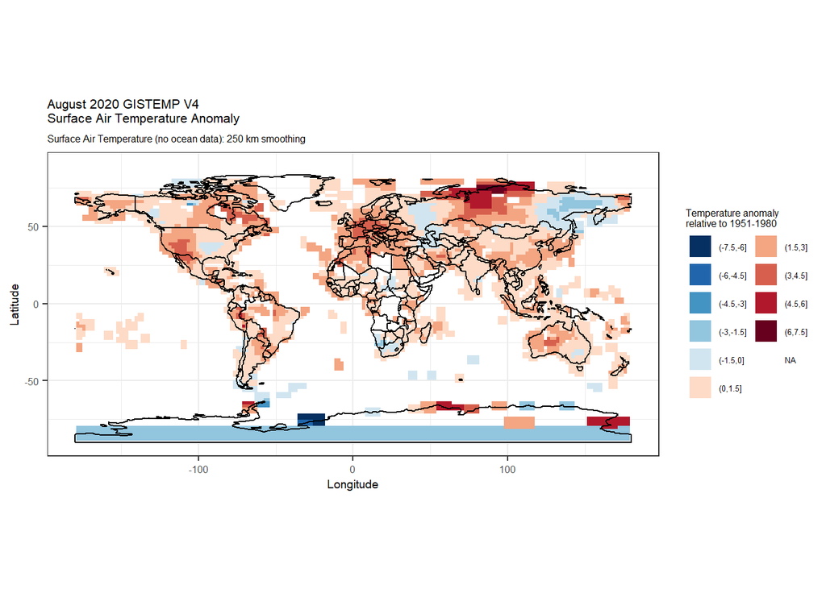

```r
## Plot august 2020 anomaly

tempCuts <- seq(-7.5, 7.5, length.out = 11)


world <- ne_countries()
rasterVis::gplot(r) +
  geom_tile(aes(fill = cut(value, tempCuts))) +
  geom_path(data = world, aes(x = long, y = lat, group = group)) +
  scale_fill_brewer(palette = "RdBu",
                    drop = FALSE,
                    direction = -1) +
  coord_equal() +
  theme_bw() +
  labs(x = "Longitude",
       y = "Latitude",
       fill = "Temperature anomaly \nrelative to 1951-1980",
       title = "August 2020 GISTEMP V4 \nSurface Air Temperature Anomaly",
       subtitle = "Surface Air Temperature (no ocean data): 250 km smoothing") +
  guides(fill = guide_legend(override.aes = list(size = 2),ncol = 2)) +
  theme(plot.title = element_text(size = 8),
        plot.subtitle = element_text(size = 6),
        legend.title = element_text(size = 6),
        legend.text = element_text(size = 5),
        axis.title = element_text(size = 7),
        axis.text = element_text(size = 6))
```

# 5 Cropping down to Australia only

```r
# colorpalette ------------------------------------------------------------

## want to go from -4 to 4 at 0.5 degrees = 17 colours
palcoolwarm <- coolwarm(n = 17)



# data --------------------------------------------------------------------

nc_data <- nc_open("D:/CampbellM1/R_learning_space/gisstemp_2020/gistemp250_GHCNv4.nc")


lon <- ncvar_get(nc_data, "lon")
lat <- ncvar_get(nc_data, "lat")
t <- ncvar_get(nc_data, "time")
tdate <- as.Date(t, origin=c('1800-01-01')) ## convert time (days since 18000101 to date)

temp.array <- ncvar_get(nc_data, "tempanomaly") #extract temp anomaly data
fillvalue <- ncatt_get(nc_data, "tempanomaly", "_FillValue")
nc_close(nc_data)

temp.array[temp.array == fillvalue$value] <- NA ## replace fill value with NA

r_brick <- brick(temp.array, xmn=min(lat), xmx=max(lat), ymn=min(lon), ymx=max(lon), crs=CRS("+proj=longlat +datum=WGS84 +no_defs"))
r_brickcorrect <- t(r_brick)
r_brickcorrect <- flip(r_brickcorrect, direction = "y")


print(r_brick)
```

```
## class      : RasterBrick
## dimensions : 180, 90, 16200, 1688  (nrow, ncol, ncell, nlayers)
## resolution : 1.977778, 1.988889  (x, y)
## extent     : -89, 89, -179, 179  (xmin, xmax, ymin, ymax)
## crs        : +proj=longlat +datum=WGS84 +no_defs
## source     : memory
## names      : layer.1, layer.2, layer.3, layer.4, layer.5, layer.6, layer.7, layer.8, layer.9, layer.10, layer.11, layer.12, layer.13, layer.14, layer.15, ...
## min values :   -9.15,  -11.53,   -8.17,   -8.62,   -3.17,   -3.92,   -4.74,   -5.08,   -4.64,    -6.73,    -9.57,   -11.84,    -7.74,    -8.96,    -6.85, ...
## max values :   10.00,    5.10,    3.84,    3.83,    4.65,    2.87,    3.47,    2.84,    2.01,     3.51,     6.64,     4.63,     6.91,     3.43,     5.16, ...
```

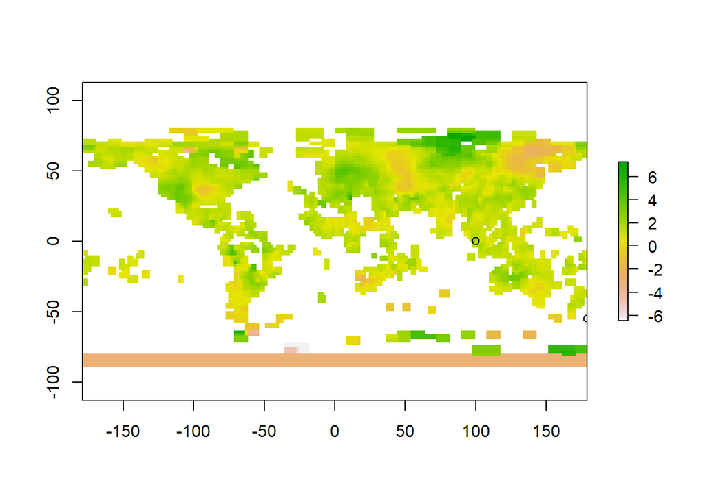

```r
plot(r_brickcorrect$layer.1688)
pr <- r_brickcorrect
pt <- cbind(c(100, 179), c(0, -55))
plot(pr[[1688]])
points(pt)
```

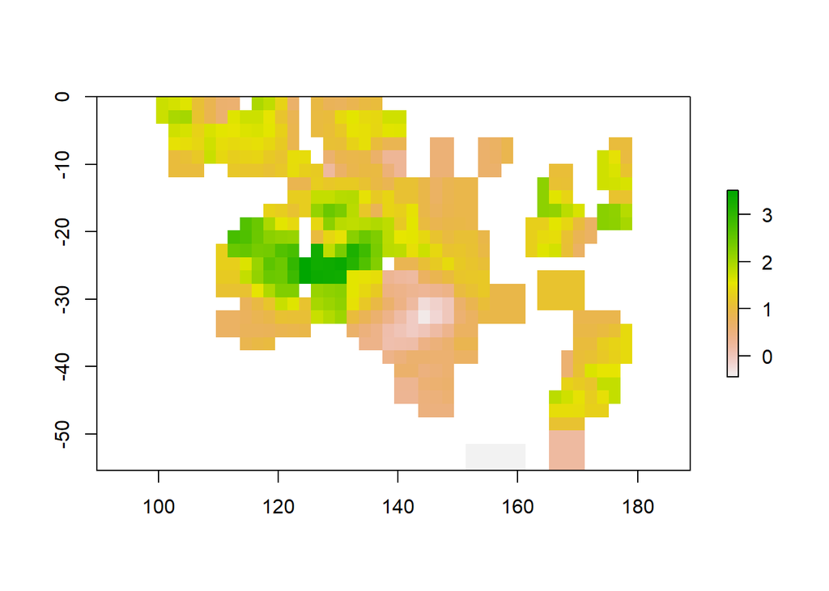

```r
cropextent <- extent(c(100, 179, -55, 0))

cropped_gistemp <- crop(r_brickcorrect, cropextent)

plot(cropped_gistemp[[1688]])
```

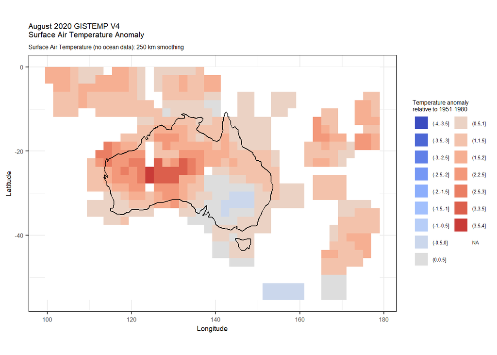

```r
tempCuts <- seq(-4, 4, length.out = 17)

aus <- ne_countries(country = "australia")
rasterVis::gplot(cropped_gistemp[[1688]]) +
  geom_tile(aes(fill = cut(value, tempCuts))) +
  geom_path(data = aus, aes(x = long, y = lat, group = group)) +
  scale_fill_manual(values = as.vector(palcoolwarm),
                    drop = FALSE,
                    na.value = "white") +
  coord_equal() +
  theme_bw() +
  labs(x = "Longitude",
       y = "Latitude",
       fill = "Temperature anomaly \nrelative to 1951-1980",
       title = "August 2020 GISTEMP V4 \nSurface Air Temperature Anomaly",
       subtitle = "Surface Air Temperature (no ocean data): 250 km smoothing") +
  guides(fill = guide_legend(override.aes = list(size = 2),ncol = 2)) +
  theme(plot.title = element_text(size = 8),
        plot.subtitle = element_text(size = 6),
        legend.title = element_text(size = 6),
        legend.text = element_text(size = 5),
        axis.title = element_text(size = 7),
        axis.text = element_text(size = 6))
```

# 6 Correlating!

Each brick has x * y cells by z monthly layers. To correlate each cell against a one-dimensional timeseries (representative of, for e.g. a single station’s data), we can use a tool from `raster`. Note that I just made up some data with trend, so the correlation is rubbish!

This uses the same `cropped_gistemp` data from the previous section.

```r
fakedata <- data.frame(t = seq(1:1688), fakey = rnorm(1688, mean = 20, sd = 1)* t^(0.2)) # make some synthetic data

fun <- function(x) { # function to apply in raster::calc
  cor(x, fakedata$fakey, method = "pearson") ## pearson's correlation of fake data and raster vals
}
x2 <- raster::calc(cropped_gistemp, fun) # correlation!

cropped_gistemp_e <- extract(cropped_gistemp, matrix(c(145, -30), ncol =2)) ## check correlation by extracting timeseries from ratserbrick
cropped_gistemp_e <- t(data.frame(y = cropped_gistemp_e)) # make useable

test <- cor(cropped_gistemp_e, fakedata$fakey) # correlation for extracted point timeseries and fake data
test
```

```
##            [,1]
## [1,] 0.03324843
```

```r
x2cor <- extract(x2, matrix(c(145, -30), ncol =2)) # extract correlation
x2cor
```

```
##
## 0.03324844
```

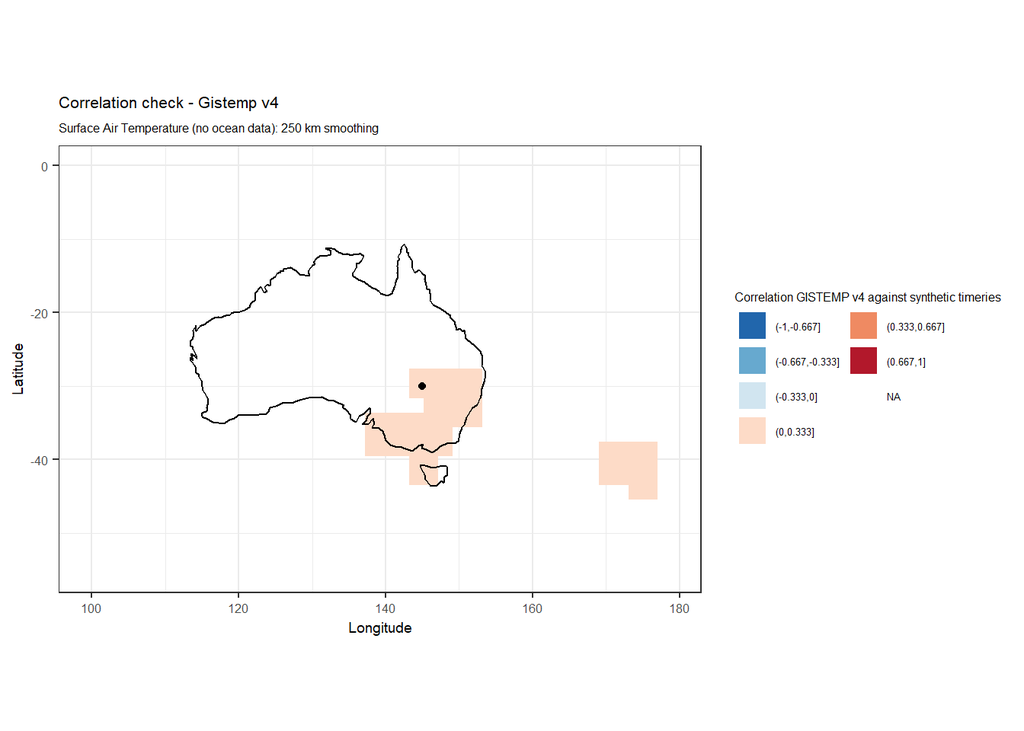

```r
tempCuts <- seq(-1, 1, length.out = 7)
aus <- ne_countries(country = "australia")
rasterVis::gplot(x2) +
  geom_tile(aes(fill = cut(value, tempCuts))) +
  geom_path(data = aus, aes(x = long, y = lat, group = group)) +
  geom_point(aes(x = 145, y = -30)) +
  scale_fill_brewer(palette = "RdBu",
                    drop = FALSE,
                    direction = -1) +
  coord_equal() +
  theme_bw() +
  labs(x = "Longitude",
       y = "Latitude",
       fill = "Correlation GISTEMP v4 against synthetic timeries",
       title = "Correlation check - Gistemp v4",
       subtitle = "Surface Air Temperature (no ocean data): 250 km smoothing") +
  guides(fill = guide_legend(override.aes = list(size = 2),ncol = 2)) +
  theme(plot.title = element_text(size = 8),
        plot.subtitle = element_text(size = 6),
        legend.title = element_text(size = 6),
        legend.text = element_text(size = 5),
        axis.title = element_text(size = 7),
        axis.text = element_text(size = 6))
```